# Exploring the Relationships Between Poverty, Unemployment, and Education in U.S. Counties

Boning Liu

2024-09-25

# Part 1 - Data Integration

## Section 1 - Problem Statement and Background

The aim of this analysis is to examine the relationships between poverty, unemployment, and educational attainment across counties in the United States. Understanding these relationships can provide insights into the socio-economic challenges that different regions face, particularly in terms of poverty alleviation and economic development.

The data for this project comes from various government sources, including the U.S. Census Bureau and the Bureau of Labor Statistics. The key datasets include Presidential Election Data, Unemployment Data, Poverty Estimates, and Education Data for the year 2020. These datasets provide rich information about the economic and social conditions in U.S. counties.

The question this analysis seeks to answer is: **how do unemployment rates and education levels influence poverty across U.S. counties?** This analysis is important for policymakers and social researchers aiming to design more effective interventions to combat poverty.

## Section 2 - Objectives of Data Integration

The main goal of combining these datasets is to create one complete dataset that lets us study how poverty, unemployment, and education are related across U.S. counties. By putting these datasets together, we can better understand how these factors affect each other and contribute to issues like inequality.

This data integration helps us look at connections between education levels and poverty, or how unemployment impacts poverty in different counties. This information can help policymakers figure out which areas need more support or targeted programs to reduce poverty.

## Section 3 - Software Programs

This project was conducted using the R programming language due to its robust suite of data analysis and visualization tools. R provides powerful packages like `dplyr` for data manipulation and `ggplot2` for visualization, allowing for efficient processing and exploration of large datasets. RMarkdown was used for documenting the project and creating reproducible reports.

## Section 4 - Data Integration

This project uses data from four major sources: Presidential Election Data, Unemployment Data, Poverty Estimates, and Education Data. The data integration process involved merging these datasets based on the county FIPS code, a unique identifier for U.S. counties.

- **Presidential Election Data**: Provides the winning political party in each county for the 2020 election.
- **Unemployment Data**: Contains county-level unemployment rates for the year 2020.
- **Poverty Data**: Provides poverty rates at the county level for 2019.
- **Education Data**: Contains data on educational attainment, specifically the percentage of people with less than a high school diploma, high school diploma, some college, and a bachelor’s degree.

### Filter Presidential Election Data (2020)

**Instructions:** The following information should be kept in the final data set:

- only use the 2020 election data
- only keep the data for the two major parties: Democrats and Republicans
- aggregate the total votes and keep the winning party in the data
- county FIPS code, State name, county name, total votes received in the winning party, and the name of the party

```r
election_2020 <- election_data %>%
  filter(year == 2020 & party %in% c("DEMOCRAT", "REPUBLICAN")) %>%
  group_by(county_fips, county_name, state) %>%
  summarize(total_votes = sum(candidatevotes),
            winning_party = ifelse(sum(candidatevotes[party == "DEMOCRAT"]) > sum(candidatevotes[party == "REPUBLICAN"]),
                                   "DEMOCRAT", "REPUBLICAN"))
election_2020_clean <- na.omit(election_2020)
```

### Filter Unemployment Data (2020)

**Instructions:** The following information should be kept in the data:

- Only keep the unemployment date in the year 2020 or the most recent year if the 2020 employment rate is unavailable
- County FIPS code
- Unemployment rate

```r
unemployment_2020 <- unemployment_data %>%
  filter(Attribute == "Unemployment_rate_2020") %>%
  select(FIPS_Code, Area_name, unemployment_rate = Value)

unemployment_2020_clean <- na.omit(unemployment_2020)
```

### Filter Poverty Data (2019)

**Instructions:** The following information should be kept in the data:

- Keep only 2019 poverty rate [the variable name in the data set: PCTPOVALL_2019]
- County FIPS code

```r
poverty_2019 <- poverty_data %>%
  filter(Attribute == "PCTPOVALL_2019") %>%
  select(FIPStxt, Area_name, poverty_rate = Value)

poverty_2019_clean <- na.omit(poverty_2019)
```

### Filter Education Data (2015-2019)

**Instructions:** The following information should be kept in the data:

- Only keep the percentage of education levels between 2015 and 2019.
- Education levels
  - less than a high school diploma
  - high school diploma
  - completed some college (1-3 years)
  - completed four years of college
- County FIPS code

```r
education_filtered <- education_data %>%
  select(
    `FIPS Code`,
    `Percent of adults with less than a high school diploma, 2015-19`,
    `Percent of adults with a high school diploma only, 2015-19`,
    `Percent of adults completing some college or associate's degree, 2015-19`,
    `Percent of adults with a bachelor's degree or higher, 2015-19`
  ) %>%
  rename(
    county_fips = `FIPS Code`,
    less_than_high_school = `Percent of adults with less than a high school diploma, 2015-19`,
    high_school = `Percent of adults with a high school diploma only, 2015-19`,
    some_college = `Percent of adults completing some college or associate's degree, 2015-19`,
    bachelors = `Percent of adults with a bachelor's degree or higher, 2015-19`
  )

education_filtered_clean <- na.omit(education_filtered)
```

### Merging all datasets

```r
# Convert FIPS columns to character in all datasets
election_2020_clean <- election_2020_clean %>%
  mutate(county_fips = as.character(county_fips))

unemployment_2020_clean <- unemployment_2020_clean %>%
  mutate(FIPS_Code = as.character(FIPS_Code))

poverty_2019_clean <- poverty_2019_clean %>%
  mutate(FIPStxt = as.character(FIPStxt))

education_filtered_clean <- education_filtered_clean %>%
  mutate(county_fips = as.character(county_fips))

# Now perform the merging with all FIPS columns as characters
final_data <- election_2020_clean %>%
  left_join(unemployment_2020_clean, by = c("county_fips" = "FIPS_Code")) %>%
  left_join(poverty_2019_clean, by = c("county_fips" = "FIPStxt")) %>%
  left_join(education_filtered_clean, by = "county_fips")
```

### Checking Size of Dataset, List of Variables & Types of Variables

Each dataset was cleaned and preprocessed before integration. We handled missing data by removing records with insufficient information.

The final cleaned dataset now has 2,824 rows (counties) and 13 columns (variables).

# Part 2 - Exploratory Data Analysis

## Section 5 - Comments on Visual Representation

### Distribution of Poverty Rate

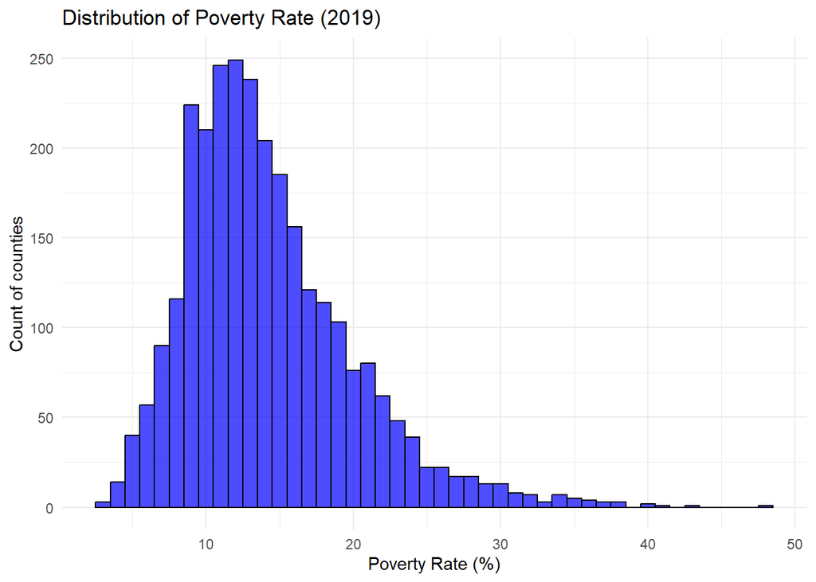

The histogram of the Distribution of Poverty Rate (2019) shows that the majority of U.S. counties have poverty rates between 5% and 15%, with the highest concentration around 10%. The distribution is right-skewed, meaning that while most counties have relatively moderate poverty rates, a smaller number of counties experience significantly higher poverty levels, with some exceeding 30%. This long tail suggests that extreme poverty is present in a limited number of counties, although such cases are less common.

### Relationship Between Poverty Rate and Unemployment Rate

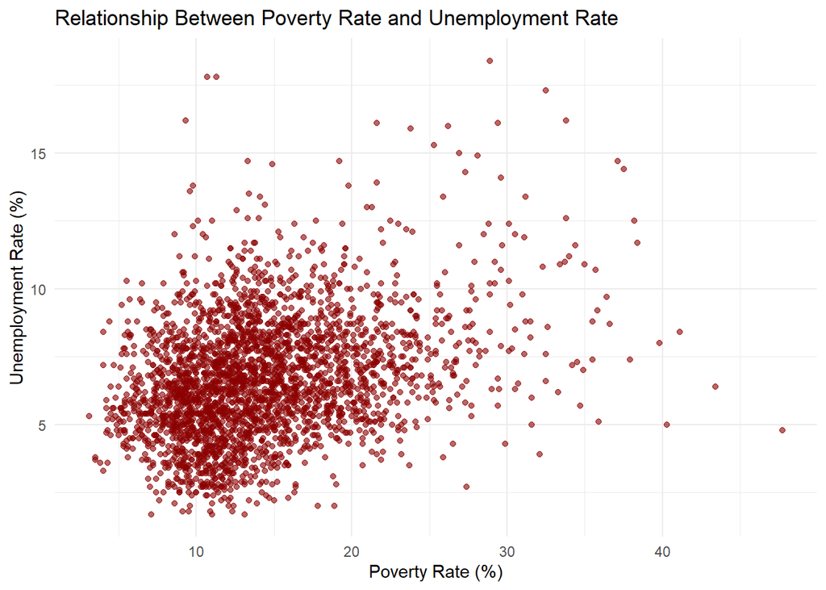

The scatterplot illustrates the relationship between the poverty rate and the unemployment rate across counties. While there is some clustering around unemployment rates of 5-10% and poverty rates of 5-15%, no strong linear trend is visible. This suggests that while higher unemployment may be linked to higher poverty rates in some cases, the relationship is not particularly strong or consistent across counties. There are several outliers with high poverty rates and moderate unemployment, indicating that other factors may also influence poverty levels.

### Pairwise Comparison: Poverty Rate vs Bachelor’s Degree

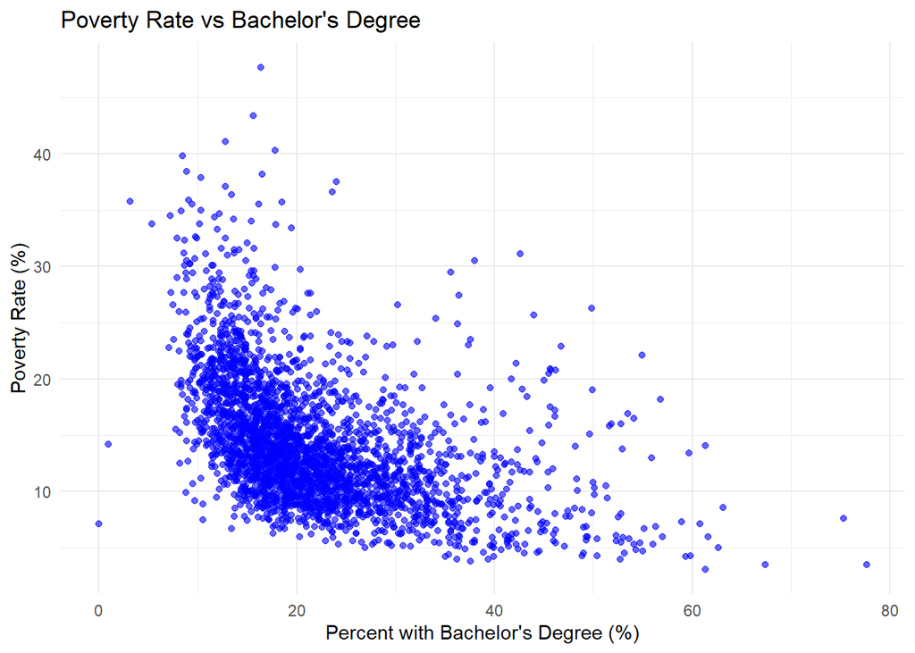

In this plot, there is a clear negative relationship between the percentage of individuals with a bachelor’s degree and the poverty rate. As the percentage of people with a bachelor’s degree increases, the poverty rate tends to decrease. Counties with higher educational attainment (bachelor’s degrees) generally have lower poverty rates, reinforcing the idea that education plays a critical role in reducing poverty.

### Pairwise Comparison: Poverty Rate vs High School Diploma

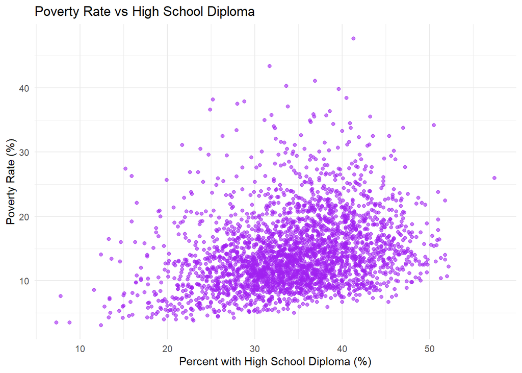

### Pairwise Comparison: Poverty Rate vs Less than High School

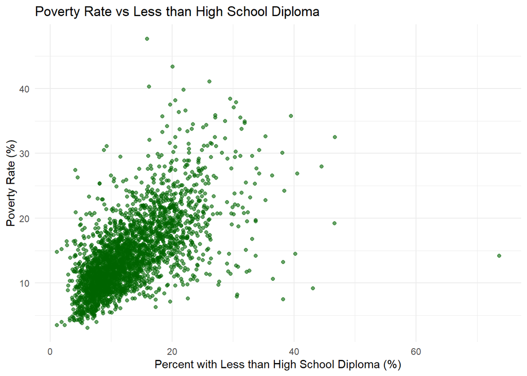

This plot indicates a positive relationship between the percentage of people with less than a high school diploma and the poverty rate. Counties with higher percentages of people who did not complete high school tend to have higher poverty rates. The data points cluster upward, indicating that as the percentage of individuals with less than a high school diploma increases, the poverty rate also tends to increase. This suggests that lower levels of educational attainment are associated with higher poverty levels in U.S. counties.

## Section 6 - Results and Discussions

The exploratory data analysis reveals several key insights. First, there is a strong negative relationship between educational attainment and poverty. Counties with a higher percentage of individuals holding a bachelor’s degree have significantly lower poverty rates, while counties with lower levels of education tend to experience higher poverty.

The relationship between unemployment and poverty is less pronounced, although counties with higher unemployment rates do tend to have higher poverty rates. This suggests that unemployment may be one of several factors contributing to poverty, but education appears to be a more significant predictor.

These findings have important policy implications. Increasing access to higher education, particularly in counties with low educational attainment, could help reduce poverty. Additionally, targeted employment programs in regions with high unemployment and poverty could help alleviate economic hardship.